# DS6306 Case Study 01

Ranjan Karki & Jason McDonald

12/18/2021

# Exploratory Data Analysis of Breweries and Beer

## Prepared for Brendan Whitworth, CEO, and Fernando Tennenbaum, CFO, of Anheuser Busch InBev

Mr. Whitworth, Mr. Tennenbaum, thank you for the opportunity to work with Anheuser Busch InBev to analyze data on a set of craft beers and the breweries that make them. We’ve received the datasets containing information on over 2400 craft beers made by over 550 breweries.

We’ve begun to explore these datasets with the intention of answering the questions you previously provided. I believe we’ve been able to extract insights that you will find valuable to Anheuser Busch InBev.

With that, if you are ready, let’s walk through our initial findings within the data.

## Question 1: How many breweries are present in each state?

### To approach this question, we were able to read in the data contained in the list of Breweries and count the number in each state. As you can see, Colorado leads with 47 breweries while 4 different states, West Virginia, South Dakota, North Dakota, and Washington DC only have 1 brewery.

```r
library(dplyr)
library(ggplot2)
library(tidyr)
#Read in Breweries.csv and setup a list with the state and count of each state, then build a barplot
Breweries <- read.csv("Breweries.csv", header = TRUE , ",")
totals <- Breweries %>% count (State)
q1 <- ggplot(data=totals, aes(x = State,y=n, fill = n, width = 0.8)) + geom_bar(stat='identity', width=0.7) + scale_fill_gradient2(midpoint=mean(totals$n), low= '#971B1E', mid = '#E02124', high = '#FFF200', space='#E1E1E1') + geom_text(aes(x= State,n +1, label = paste(State, n, sep=' - ')), data = totals, position = position_dodge(width = 1), hjust = -0.1, size = 4) + ggtitle("Total Breweries in each State") + coord_flip() + theme(legend.title = element_text(colour='#331D0C')) + labs(fill="Count of Breweries", y = "Count of Breweries") + scale_y_continuous(limits = c(0,max(totals$n) *1.1))
```

### The below barplot displays the count of breweries per state.

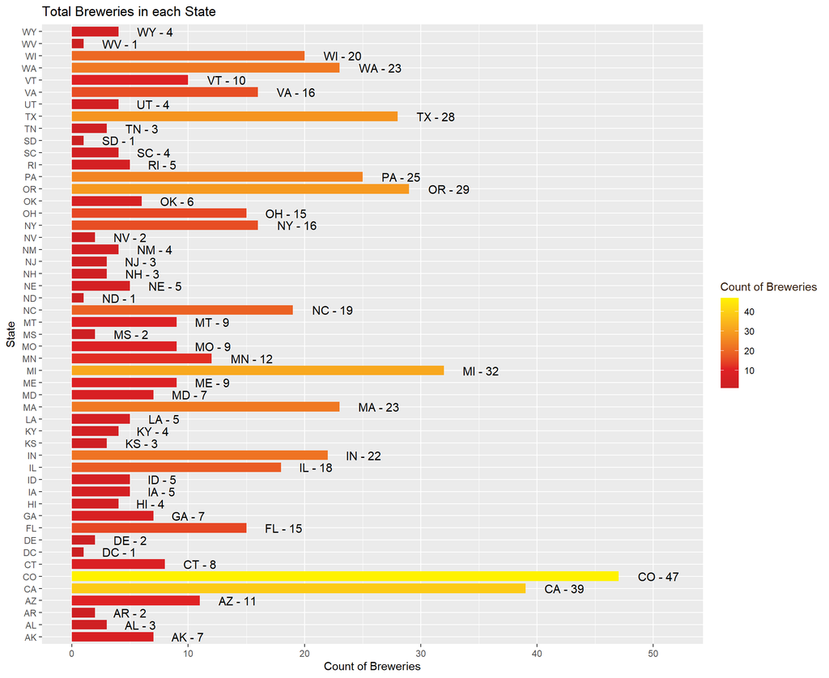

```r
q1
```

## Question 2: Merge beer data with the breweries data. Print the first 6 observations and the last six observations to check the merged file. (RMD only, this does not need to be included in the presentation or the deck.)

```r
Beers <- read.csv("Beers.csv", header = TRUE , ",")
BeerN <- rename(Beers,"Brew_ID" = "Brewery_id")
tdf <- merge(BeerN,Breweries, by = "Brew_ID", na.rm = True) %>% rename(Beer = Name.x, Brewery = Name.y)

#View(tdf)
head(tdf,n=6)
```

```
##   Brew_ID          Beer Beer_ID   ABV IBU                               Style
## 1       1  Get Together    2692 0.045  50                        American IPA
## 2       1 Maggie's Leap    2691 0.049  26                  Milk / Sweet Stout
## 3       1    Wall's End    2690 0.048  19                   English Brown Ale
## 4       1       Pumpion    2689 0.060  38                         Pumpkin Ale
## 5       1    Stronghold    2688 0.060  25                     American Porter
## 6       1   Parapet ESB    2687 0.056  47 Extra Special / Strong Bitter (ESB)
##   Ounces            Brewery        City State
## 1     16 NorthGate Brewing  Minneapolis    MN
## 2     16 NorthGate Brewing  Minneapolis    MN
## 3     16 NorthGate Brewing  Minneapolis    MN
## 4     16 NorthGate Brewing  Minneapolis    MN
## 5     16 NorthGate Brewing  Minneapolis    MN
## 6     16 NorthGate Brewing  Minneapolis    MN
```

```r
tail (tdf,n=6)
```

```
##      Brew_ID                      Beer Beer_ID   ABV IBU
## 2405     556             Pilsner Ukiah      98 0.055  NA
## 2406     557  Heinnieweisse Weissebier      52 0.049  NA
## 2407     557           Snapperhead IPA      51 0.068  NA
## 2408     557         Moo Thunder Stout      50 0.049  NA
## 2409     557         Porkslap Pale Ale      49 0.043  NA
## 2410     558 Urban Wilderness Pale Ale      30 0.049  NA
##                        Style Ounces                       Brewery          City
## 2405         German Pilsener     12         Ukiah Brewing Company         Ukiah
## 2406              Hefeweizen     12       Butternuts Beer and Ale Garrattsville
## 2407            American IPA     12       Butternuts Beer and Ale Garrattsville
## 2408      Milk / Sweet Stout     12       Butternuts Beer and Ale Garrattsville
## 2409 American Pale Ale (APA)     12       Butternuts Beer and Ale Garrattsville
## 2410        English Pale Ale     12 Sleeping Lady Brewing Company     Anchorage
##      State
## 2405    CA
## 2406    NY
## 2407    NY
## 2408    NY
## 2409    NY
## 2410    AK
```

```r
###EXTRA
top_n(tdf,6,Brew_ID)
```

```
##   Brew_ID                      Beer Beer_ID   ABV IBU                   Style
## 1     556             Pilsner Ukiah      98 0.055  NA         German Pilsener
## 2     557  Heinnieweisse Weissebier      52 0.049  NA              Hefeweizen
## 3     557           Snapperhead IPA      51 0.068  NA            American IPA
## 4     557         Moo Thunder Stout      50 0.049  NA      Milk / Sweet Stout
## 5     557         Porkslap Pale Ale      49 0.043  NA American Pale Ale (APA)
## 6     558 Urban Wilderness Pale Ale      30 0.049  NA        English Pale Ale
##   Ounces                       Brewery          City State
## 1     12         Ukiah Brewing Company         Ukiah    CA
## 2     12       Butternuts Beer and Ale Garrattsville    NY
## 3     12       Butternuts Beer and Ale Garrattsville    NY
## 4     12       Butternuts Beer and Ale Garrattsville    NY
## 5     12       Butternuts Beer and Ale Garrattsville    NY
## 6     12 Sleeping Lady Brewing Company     Anchorage    AK
```

## Question 3: Address the missing values in each column.

### We found 1005 beers which didn’t have an IBU value and 62 that didn’t have an ABV. As your questions pertain to these values and there is no method that we can use to approximate the missing values, removing these beers from the dataset was the only option when that variable is used in the analysis.

```r
colSums(is.na(tdf))
```

```
## Brew_ID    Beer Beer_ID     ABV     IBU   Style  Ounces Brewery    City   State
##       0       0       0      62    1005       0       0       0       0       0
```

```r
#Setup DF where we'll strip out missing data

dtdf_RemoveNA_ABV <- tdf
dtdf_RemoveNA_IBU <- tdf
dtdf <- tdf

### assigning to new data frame
dtdf_RemoveNA_ABV <- dtdf_RemoveNA_ABV[!is.na(tdf$ABV), ]
dtdf_RemoveNA_IBU <- dtdf_RemoveNA_IBU [!is.na(tdf$IBU), ]
dtdf <- dtdf[!is.na(dtdf$ABV), ]
dtdf <- dtdf[!is.na(dtdf$IBU), ]

colSums(is.na(dtdf_RemoveNA_ABV))
```

```
## Brew_ID    Beer Beer_ID     ABV     IBU   Style  Ounces Brewery    City   State
##       0       0       0       0     943       0       0       0       0       0
```

```r
colSums(is.na(dtdf_RemoveNA_IBU))
```

```
## Brew_ID    Beer Beer_ID     ABV     IBU   Style  Ounces Brewery    City   State
##       0       0       0       0       0       0       0       0       0       0
```

```r
colSums(is.na(dtdf))
```

```
## Brew_ID    Beer Beer_ID     ABV     IBU   Style  Ounces Brewery    City   State
##       0       0       0       0       0       0       0       0       0       0
```

## Question 4: Compute the median alcohol content and international bitterness unit for each state. Plot a bar chart to compare.

### To identify the median ABV and IBU by state, we performed a calculation on the dataset, grouping by state and finding the mediam in each. We then generated barplots as seen here.

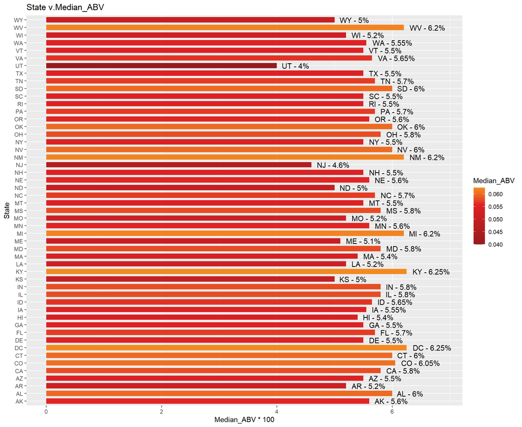

```r
df1 <- dtdf_RemoveNA_ABV %>% group_by(State) %>% summarise(Median_ABV = median(ABV))
ggplot(data = df1, aes(x= State, y = Median_ABV * 100 ,fill = Median_ABV))+geom_bar(stat='identity', width=0.7) + ggtitle ("State v.Median_ABV") + scale_fill_gradient2(midpoint=mean(df1$Median_ABV), low= '#971B1E', mid = '#E02124', high = '#FFF200', space='#E1E1E1') + coord_flip() + geom_text(data = df1, aes(x = State, label = paste(State, paste(Median_ABV * 100, '%', sep = ''), sep=' - ')), position = position_dodge(width = 1), hjust = -0.1, size = 4) + scale_y_continuous(limits = c(0,max(df1$Median_ABV * 100) *1.1))
```

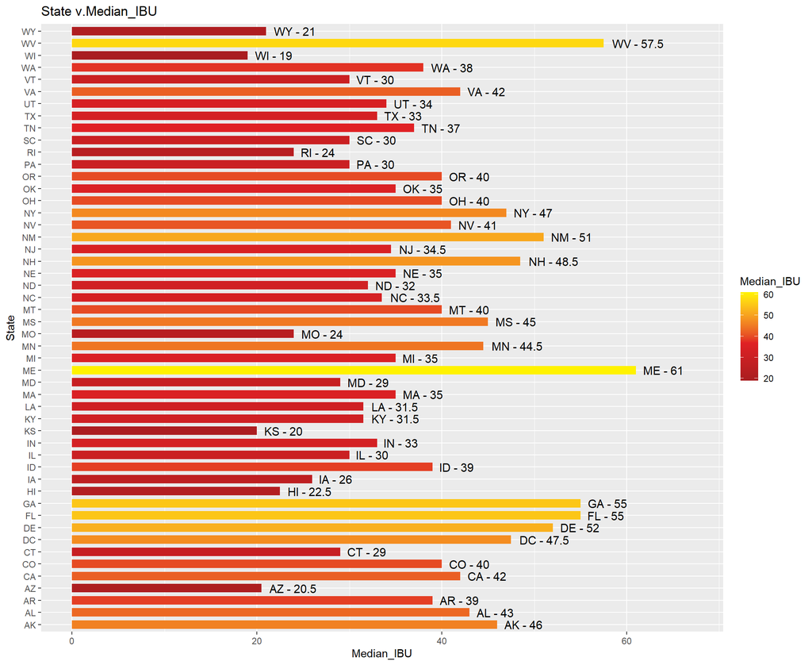

```r
## question how can I do both at the same time


df2 <- dtdf_RemoveNA_IBU %>% group_by(State) %>% summarise(Median_IBU = median(IBU))
ggplot(data = df2, aes(x= State, y = Median_IBU ,fill = Median_IBU))+geom_bar(stat='identity', width=0.7)+ ggtitle ("State v.Median_IBU") + scale_fill_gradient2(midpoint=mean(df2$Median_IBU), low= '#971B1E', mid = '#E02124', high = '#FFF200', space='#E1E1E1') + coord_flip() + geom_text(data = df2, aes(x = State, label = paste(State, Median_IBU, sep=' - ')), position = position_dodge(width = 1), hjust = -0.1, size = 4) + scale_y_continuous(limits = c(0,max(df2$Median_IBU) *1.1))
```

## Question 5: Which state has the maximum alcoholic (ABV) beer? Which state has the most bitter (IBU) beer?

### We analyzed this in two ways. We wanted to see where the highest median ABV and IBU was located, along with the single highest ABV and IBU locations and details of those specific beers.

### For the maximum median ABV, we found both Washington DC and Kentucky having a median ABV of 6.25%. As for the single highest ABV, Colorado’s Upslope Brewing Company’s Lee Hill Series Volume 5 comes in with a max ABV of 12.8%.

### For the maximum median IBU, Maine came in with a 61 median IBU. For the individual beer with the highest IBU, from Oregon, Astoria Brewing Company’s Bitter Bitch Imperial IPA has an IBU of 138.

```r
#row number with of max value can be obtained by which.max, to get all information using by subsetting data frame.

df1[which.max(df1$Median_ABV),] ###Kentucky and DC
```

```
## # A tibble: 1 x 2
##   State Median_ABV
##   <chr>      <dbl>
## 1 " DC"     0.0625
```

```r
dtdf_RemoveNA_ABV[which.max(dtdf_RemoveNA_ABV$ABV),]
```

```
##     Brew_ID                                                 Beer Beer_ID   ABV
## 375      52 Lee Hill Series Vol. 5 - Belgian Style Quadrupel Ale    2565 0.128
##     IBU            Style Ounces                 Brewery    City State
## 375  NA Quadrupel (Quad)   19.2 Upslope Brewing Company Boulder    CO
```

```r
#IF we need to show the single highest ABV and IBU beers
#tail(arrange(dtdf, ABV))

df2[which.max(df2$Median_IBU),]  ###Maine
```

```
## # A tibble: 1 x 2
##   State Median_IBU
##   <chr>      <dbl>
## 1 " ME"         61
```

```r
dtdf_RemoveNA_IBU[which.max(dtdf_RemoveNA_IBU$IBU),]
```

```
##      Brew_ID                      Beer Beer_ID   ABV IBU
## 1857     375 Bitter Bitch Imperial IPA     980 0.082 138
##                               Style Ounces                 Brewery    City
## 1857 American Double / Imperial IPA     12 Astoria Brewing Company Astoria
##      State
## 1857    OR
```

## Question 6: Comment on the summary statistics and distribution of the ABV variable.

```r
summary(dtdf$ABV)
```

```
##    Min. 1st Qu.  Median    Mean 3rd Qu.    Max.
## 0.02700 0.05000 0.05700 0.05991 0.06800 0.12500
```

```r
sd(dtdf_RemoveNA_ABV$ABV*100)   ###0.005437061
```

```
## [1] 1.354173
```

```r
mean(dtdf_RemoveNA_ABV$ABV*100)  ### 0.05564
```

```
## [1] 5.977342
```

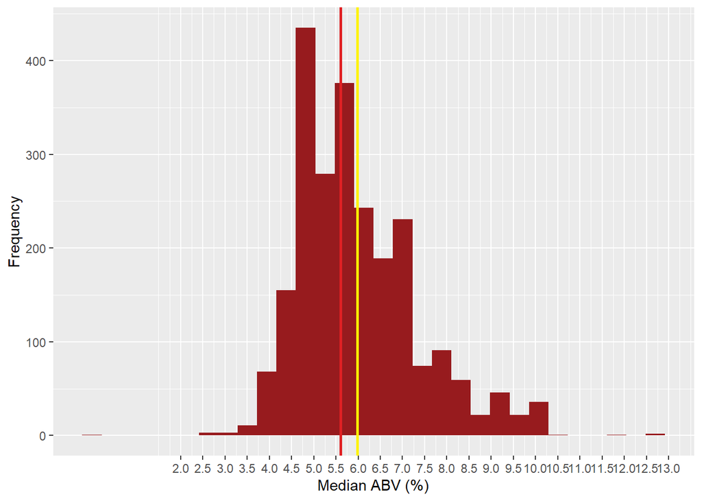

```r
ggplot(dtdf_RemoveNA_ABV, aes(x = ABV*100)) + geom_histogram(aes(y = ..count..), fill = '#971B1E') + scale_y_continuous(name = "Frequency") + theme(legend.position = 'none') + scale_x_continuous(name = 'Median ABV (%)', breaks = seq(2,13,.5)) + geom_vline(aes(xintercept = mean(dtdf_RemoveNA_ABV$ABV *100)),col='#FFF200',size=1) + geom_vline(aes(xintercept = median(dtdf_RemoveNA_ABV$ABV *100)),col='#E02124',size=1)
```

## Question 7: Is there an apparent relationship between the bitterness of the beer and its alcoholic content? Draw a scatter plot. Make your best judgment of a relationship and EXPLAIN your answer.

### While there appears to be some positive relationship between ABV and IBU, it appears to be somewhat weak. There are numerous outliers, specifically those with a high ABV but low IBU, that don’t fit well within that explanation. This isn’t unexpected upon additional review of the data, as seen below, as IPAs are known for their bitterness and higher alcohol content. Taking a look at what type of beers have the highest ABV while the lowest IBU shows that that group consists primarily with beers you would expect to find lower IBUs such as Ales and Witbeer.

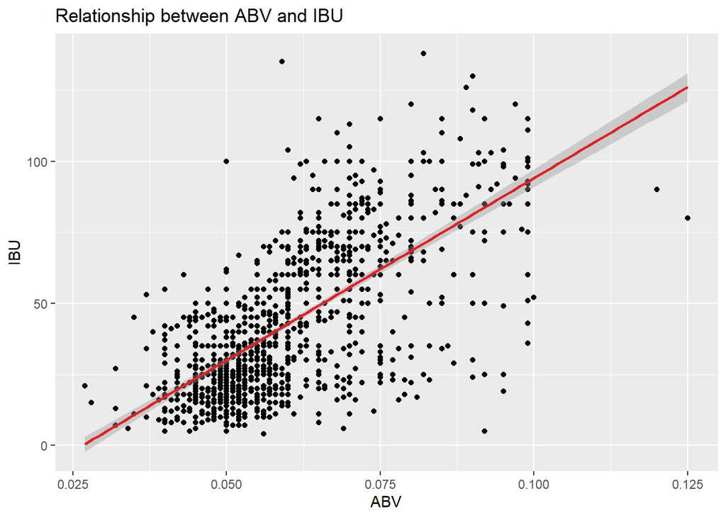

```r
dtdf %>% ggplot(aes(x=ABV,y= IBU)) + geom_point() + geom_smooth (formula = y~ x,method="lm",col='#E02124',size=1) + ggtitle(("Relationship between ABV and IBU"))
```

```r
outliers <- dtdf[dtdf$ABV > 0.075, ]
outliers <- outliers[outliers$IBU < 25, ]
outliers['Style']
```

```
##                       Style
## 178  Scotch Ale / Wee Heavy
## 199        Quadrupel (Quad)
## 225                  Dubbel
## 491   MÃ¤rzen / Oktoberfest
## 590  Fruit / Vegetable Beer
## 1266    American Strong Ale
## 1491           Scottish Ale
## 1645                Witbier
## 1762                 Tripel
## 2188           Scottish Ale
```

### Question 8: Budweiser would also like to investigate the difference with respect to IBU and ABV between IPAs (India Pale Ales) and other types of Ale (any beer with “Ale” in its name other than IPA). You decide to use KNN classification to investigate this relationship. Provide statistical evidence one way or the other. You can of course assume your audience is comfortable with percentages … KNN is very easy to understand conceptually.

### We chose to use a K nearest neighbors machine learning algorithm to attempt to define the relationship between IBU and ABV among the IPA and other Ale type craft beers. We found that we can identify with approximatly 80% success whether a particular beer is an IPA or other Ale from those data points.

```r
library(dplyr)
library(class)
library(caret)
library(stringr)

tdf <- merge(BeerN,Breweries, by = "Brew_ID", na.rm = True) %>% rename(Beer = Name.x, Brewery = Name.y)

TD <- tdf %>% filter(grepl('IPA|Ale',Style,ignore.case = T))

TD = TD[!is.na(TD$ABV),]

TD= TD[!is.na(TD$IBU), ]

#dim(TD)
#get just the 3 relevant columns and get rid of the rest
TDSubset <- select(TD, ABV, IBU, Style)
#make style a character from factor
TDSubset$Style <- as.character(TDSubset$Style)

#make all IPA's have Style of IPA and all ales have simply ale - eliminates all of the additional types to act on them as all the same In response to Novin'ssuggestion to Ranjan, changing to 0 = ipa and 1 = ale
for (i in 1:nrow(TDSubset)) {
  if (is.na(str_match(TDSubset[i, 3], 'Ale'))) {
    TDSubset[i,3] <- 0
    }
  else {
    TDSubset[i,3] <- 1
    }
  }

head(TDSubset)
```

```
##     ABV IBU Style
## 1 0.045  50     0
## 2 0.048  19     1
## 3 0.060  38     1
## 4 0.080  68     0
## 5 0.042  42     1
## 6 0.066  21     1
```

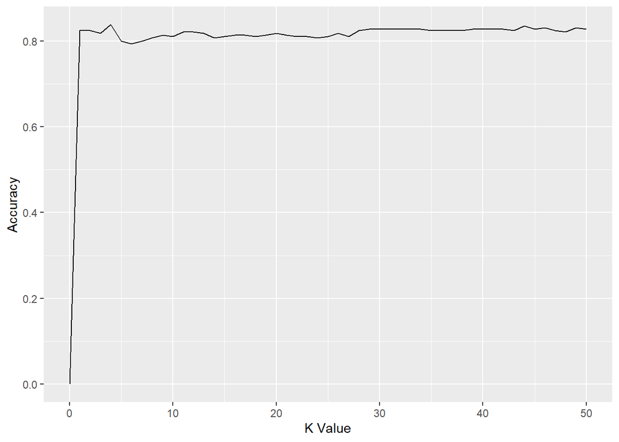

```r
#take 70% of the TDSubset to use as train and the remainder as test
ind = sample((1:nrow(TDSubset)),.7*nrow(TDSubset))
train = TDSubset[ind,]
test = TDSubset[-ind,]

pred = c("ABV","IBU")

#run 50 iterations to test the best value of K to test the best accuracy
bestKResults <- data.frame(Acc = numeric(100), k = numeric(100))
for (i in 1:50) {
  class <- knn(train[,pred],test[,pred],train$Style , prob= TRUE, k= i)
  conMatrix <- confusionMatrix(table(class, test$Style))
  bestKResults$Acc[i] <- conMatrix$overall[1]
  bestKResults$k[i] <- i

}

ggplot(bestKResults, aes(x=k, y = Acc)) + geom_line()+ labs(x = "K Value", y = "Accuracy")
```

```r
classifications = knn(train[,pred],test[,pred],train$Style , prob= TRUE, k= 17)
confusionMatrix(table(classifications, test$Style))
```

```
## Confusion Matrix and Statistics
##
##
## classifications   0   1
##               0  83  15
##               1  39 153
##
##                Accuracy : 0.8138
##                  95% CI : (0.7641, 0.8569)
##     No Information Rate : 0.5793
##     P-Value [Acc > NIR] : < 2.2e-16
##
##                   Kappa : 0.6074
##
##  Mcnemar's Test P-Value : 0.001749
##
##             Sensitivity : 0.6803
##             Specificity : 0.9107
##          Pos Pred Value : 0.8469
##          Neg Pred Value : 0.7969
##              Prevalence : 0.4207
##          Detection Rate : 0.2862
##    Detection Prevalence : 0.3379
##       Balanced Accuracy : 0.7955
##
##        'Positive' Class : 0
##
```

### Question 9: According to[Craft Beer Me](https://craftbeerme.com/guide-to-the-most-popular-types-of-craft-beer-in-america/), the 3 most popular beer styles in the US are from most to least, Lager, IPA, and American Pale Ale.

### With Budweiser being a Lager, we wanted to see how Budweiser stacks up against other craft beer lagers and offer some insight into IPA and American Pale Ales. This may be of particular use if Budweiser chose to add an IPa to compliment the existing lager and American Ale beers that are enjoyed by customers today.

```r
#create df for each lager, ipa, and apa, then remove all na IBU which will also remove any na abv as all na abv also have missing ibu
lagerDF <- tdf %>% filter(grepl('lager',Style,ignore.case = T))
ipaDF <- tdf %>% filter(grepl('IPA',Style,ignore.case = T))
paleAleDF <- tdf %>% filter(grepl('american pale ale',Style,ignore.case = T))
lagerDF <- lagerDF[!is.na(lagerDF$IBU), ]
ipaDF <- ipaDF[!is.na(ipaDF$IBU), ]
paleAleDF <- paleAleDF[!is.na(paleAleDF$IBU), ]

#Find the max, min, and median ABV and IBU for each of the top 3 beer styles
lagerDF[which.max(lagerDF$IBU),]
```

```
##   Brew_ID       Beer Beer_ID   ABV IBU                     Style Ounces
## 2       3 Excess IPL    2671 0.072  80 American India Pale Lager     16
##                    Brewery       City State
## 2 Jack's Abby Craft Lagers Framingham    MA
```

```r
lagerDF[which.min(lagerDF$IBU),]
```

```
##    Brew_ID           Beer Beer_ID   ABV IBU                  Style Ounces
## 33     130 American Lager    2233 0.041   8 American Adjunct Lager     12
##           Brewery      City State
## 33 Straub Brewery St Mary's    PA
```

```r
lagerDF[which.max(lagerDF$ABV),]
```

```
##   Brew_ID       Beer Beer_ID   ABV IBU                     Style Ounces
## 2       3 Excess IPL    2671 0.072  80 American India Pale Lager     16
##                    Brewery       City State
## 2 Jack's Abby Craft Lagers Framingham    MA
```

```r
lagerDF[which.min(lagerDF$ABV),]
```

```
##    Brew_ID           Beer Beer_ID   ABV IBU       Style Ounces        Brewery
## 35     130 American Light    2231 0.032  13 Light Lager     12 Straub Brewery
##         City State
## 35 St Mary's    PA
```

```r
medianLagerIBU <- lagerDF %>% summarise(Median_IBU = median(IBU))
medianLagerABV <- lagerDF %>% summarise(Median_ABV = median(ABV))
medianLagerABV$Median_ABV
```

```
## [1] 0.049
```

```r
medianLagerIBU$Median_IBU
```

```
## [1] 19
```

```r
ipaDF[which.max(ipaDF$IBU),]
```

```
##     Brew_ID                      Beer Beer_ID   ABV IBU
## 462     375 Bitter Bitch Imperial IPA     980 0.082 138
##                              Style Ounces                 Brewery    City State
## 462 American Double / Imperial IPA     12 Astoria Brewing Company Astoria    OR
```

```r
ipaDF[which.min(ipaDF$IBU),]
```

```
##     Brew_ID                                 Beer Beer_ID   ABV IBU
## 277     200 Lights Out Vanilla Cream Extra Stout    1513 0.077  30
##                              Style Ounces                Brewery City State
## 277 American Double / Imperial IPA     12 Worthy Brewing Company Bend    OR
```

```r
ipaDF[which.max(ipaDF$ABV),]
```

```
##    Brew_ID             Beer Beer_ID   ABV IBU                          Style
## 40      25 Hopkick Dropkick    2471 0.099 115 American Double / Imperial IPA
##    Ounces          Brewery          City State
## 40     12 Burn 'Em Brewing Michigan City    IN
```

```r
ipaDF[which.min(ipaDF$ABV),]
```

```
##    Brew_ID      Beer Beer_ID   ABV IBU        Style Ounces
## 66      35 Even Keel    2105 0.038  40 American IPA     12
##                          Brewery      City State
## 66 Ballast Point Brewing Company San Diego    CA
```

```r
medianIPAIBU <- ipaDF %>% summarise(Median_IBU = median(IBU))
medianIPAABV <- ipaDF %>% summarise(Median_ABV = median(ABV))
medianIPAABV$Median_ABV
```

```
## [1] 0.068
```

```r
medianIPAIBU$Median_IBU
```

```
## [1] 70
```

```r
paleAleDF[which.max(paleAleDF$IBU),]
```

```
##    Brew_ID                   Beer Beer_ID   ABV IBU                   Style
## 69     136 Over the Rail Pale Ale     711 0.057  68 American Pale Ale (APA)
##    Ounces            Brewery   City State
## 69     12 Pug Ryan's Brewery Dillon    CO
```

```r
paleAleDF[which.min(paleAleDF$IBU),]
```

```
##     Brew_ID                  Beer Beer_ID   ABV IBU                   Style
## 165     330 Bronx Summer Pale Ale    1748 0.052  16 American Pale Ale (APA)
##     Ounces           Brewery  City State
## 165     16 The Bronx Brewery Bronx    NY
```

```r
paleAleDF[which.max(paleAleDF$ABV),]
```

```
##     Brew_ID              Beer Beer_ID  ABV IBU                   Style Ounces
## 101     169 The Power of Zeus    2294 0.07  68 American Pale Ale (APA)     12
##               Brewery    City State
## 101 High Hops Brewery Windsor    CO
```

```r
paleAleDF[which.min(paleAleDF$ABV),]
```

```
##     Brew_ID                            Beer Beer_ID   ABV IBU
## 210     449 Back in the Saddle Rye Pale Ale    1047 0.037  53
##                       Style Ounces                Brewery          City State
## 210 American Pale Ale (APA)     12 Mavericks Beer Company Half Moon Bay    CA
```

```r
medianAPAIBU <- paleAleDF %>% summarise(Median_IBU = median(IBU))
medianAPAABV <- paleAleDF %>% summarise(Median_ABV = median(ABV))
medianAPAABV$Median_ABV
```

```
## [1] 0.055
```

```r
medianAPAIBU$Median_IBU
```

```
## [1] 44
```

```r
regions <- read.csv("states_by_region.csv", header = TRUE , ",")

#regions has State.Code
#ipaDF has State
#need to mutate to join State.Code to ipaDF


regions <- regions %>% rename(StateName = State, State = State.Code)
regions$State <- trimws(as.character(regions$State), which = c("both"), whitespace = "[ \t\r\n]")
ipaDF$State <- trimws(as.character(ipaDF$State), which = c("both"), whitespace = "[ \t\r\n]")
#head(regions)
#head(ipaDF)
ipaDF <-  merge(x=ipaDF,y=regions, by = "State", all.x=TRUE)
head(ipaDF)
```

```
##   State Brew_ID                         Beer Beer_ID   ABV IBU        Style
## 1    AK     103              King Street IPA    1667 0.060  70 American IPA
## 2    AK     224                Pleasure Town    2093 0.063  61 American IPA
## 3    AK     224            Pleasure Town IPA    1814 0.063  61 American IPA
## 4    AK     494              Fairweather IPA     648 0.061  64 American IPA
## 5    AK     454 Twister Creek India Pale Ale     947 0.065  71 American IPA
## 6    AK     224              Sockeye Red IPA     434 0.057  70 American IPA
##   Ounces                      Brewery      City StateName Region Division
## 1     12  King Street Brewing Company Anchorage    Alaska   West  Pacific
## 2     12 Midnight Sun Brewing Company Anchorage    Alaska   West  Pacific
## 3     12 Midnight Sun Brewing Company Anchorage    Alaska   West  Pacific
## 4     12 Broken Tooth Brewing Company Anchorage    Alaska   West  Pacific
## 5     12       Denali Brewing Company Talkeetna    Alaska   West  Pacific
## 6     12 Midnight Sun Brewing Company Anchorage    Alaska   West  Pacific
```

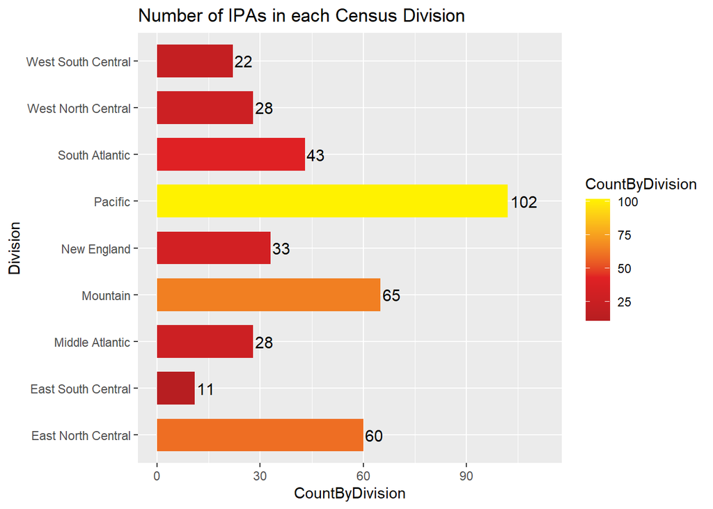

```r
#sumnmarise a count of IPAs, median abv and ibu by region

ipaCountByDivision <- ipaDF %>% group_by(Division) %>% summarise(CountByDivision = n())
ipaMedianABVByDivision <- ipaDF %>% group_by(Division) %>% summarise(Median_ABV = median(ABV))
ipaMedianIBUByDivision <- ipaDF %>% group_by(Division) %>% summarise(Median_IBU = median(IBU))

#Plot the counts by division
ggplot(data = ipaCountByDivision, aes(x= Division, y = CountByDivision ,fill = CountByDivision))+geom_bar(stat='identity', width=0.7)+ ggtitle ("Number of IPAs in each Census Division") + scale_fill_gradient2(midpoint=mean(ipaCountByDivision$CountByDivision), low= '#971B1E', mid = '#E02124', high = '#FFF200', space='#E1E1E1') + coord_flip() + geom_text(data = ipaCountByDivision, aes(x = Division, label = CountByDivision), position = position_dodge(width = 1), hjust = -0.1, size = 4) + scale_y_continuous(limits = c(0,max(ipaCountByDivision$CountByDivision) *1.1))
```

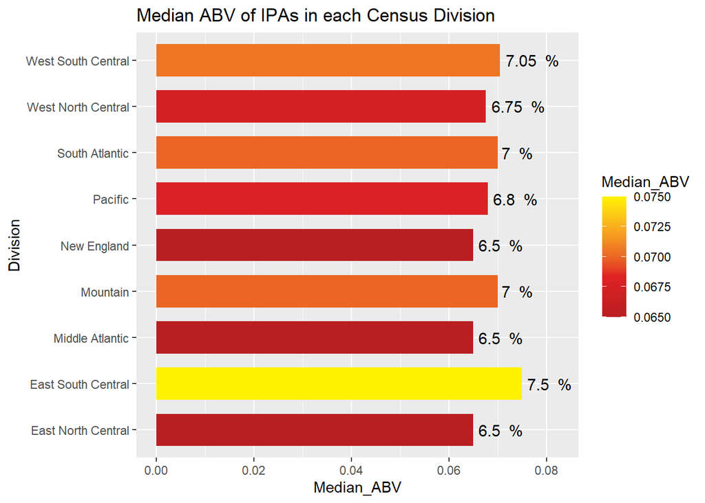

```r
#Plot the median ABV by division
ggplot(data = ipaMedianABVByDivision, aes(x= Division, y = Median_ABV ,fill = Median_ABV))+geom_bar(stat='identity', width=0.7)+ ggtitle ("Median ABV of IPAs in each Census Division") + scale_fill_gradient2(midpoint=mean(ipaMedianABVByDivision$Median_ABV), low= '#971B1E', mid = '#E02124', high = '#FFF200', space='#E1E1E1') + coord_flip() + geom_text(data = ipaMedianABVByDivision, aes(x = Division, label = paste(Median_ABV*100, " %", "" )), position = position_dodge(width = 1), hjust = -0.1, size = 4) + scale_y_continuous(limits = c(0,max(ipaMedianABVByDivision$Median_ABV) *1.1))
```

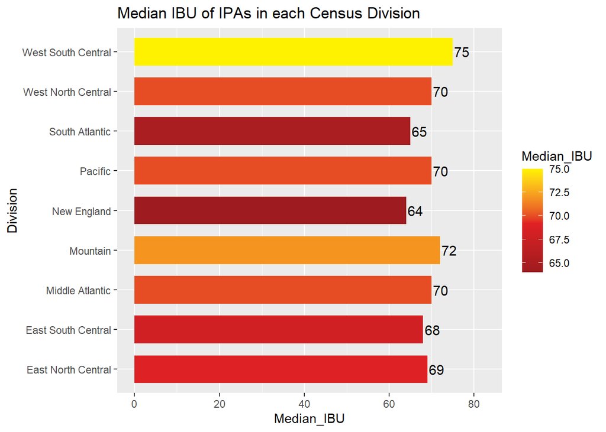

```r
#Plot the median IBU by Division
ggplot(data = ipaMedianIBUByDivision, aes(x= Division, y = Median_IBU ,fill = Median_IBU))+geom_bar(stat='identity', width=0.7)+ ggtitle ("Median IBU of IPAs in each Census Division") + scale_fill_gradient2(midpoint=mean(ipaMedianIBUByDivision$Median_IBU), low= '#971B1E', mid = '#E02124', high = '#FFF200', space='#E1E1E1') + coord_flip() + geom_text(data = ipaMedianIBUByDivision, aes(x = Division, label = Median_IBU), position = position_dodge(width = 1), hjust = -0.1, size = 4) + scale_y_continuous(limits = c(0,max(ipaMedianIBUByDivision$Median_IBU) *1.1))
```

## Comparing craft lagers to Budweiser

### As recommended by the Budweiser websites ‘Where to buy’ search, I have used data from Publix, an American grocery market, to get the ABV and IBU for Budwesier beer.

### [Publix](https://www.publix.com/pd/budweiser-beer/RIO-PCI-148406) lists Budwesier’s ABV as 5% and the IBU as 11.

### For Lagers among the craft brewers, we found the following:

| Measure | Value |
| --- | --- |
| Max ABV | 7.2% |
| Min ABV | 3.2% |
| Max IBU | 80 |
| Min IBU | 8 |
| Median ABV | 4.9% |
| Median IBU | 19 |

### For India Pale Ales among the craft brewers, we found the following:

| Measure | Value |
| --- | --- |
| Max ABV | 9.9% |
| Min ABV | 3.8% |
| Max IBU | 138 |
| Min IBU | 30 |
| Median ABV | 6.8% |
| Median IBU | 70 |

### For American Pale Ales among the craft brewers, we found the following:

| Measure | Value |
| --- | --- |
| Max ABV | 7.0% |
| Min ABV | 3.7% |
| Max IBU | 68 |
| Min IBU | 16 |
| Median ABV | 5.5% |
| Median IBU | 44 |

### What we’re demonstrating with these values and with the charts above is that should Budweiser look to extend on their existing Lager and American Ale products with a Budweiser IPA, potential divisions of the United States could provide insight into what the median ABV and median IBU values are in the respective division. For example, with only 11 IPAs being made in the East South Central, the market there may be prime for a new Budweiser IPA. The median ABV in that division is 7.5%, which does show to be the highest median ABV of any division. The median IBU in the East South Central is a 68.